# ‘2023’ Live Cricket Match Winner Predictions

INFO 523 - Project Final

Using Prediction Model to predict Live ODI Cricket Match Winners

Author

Affiliation

Christian Ortmann  
Pappala Praveen Kumar  
Poonkundran Srinivasan  
Srinivasan Akash  
Theeda Gowtham  
Tiruthani Rajitha Reddy  
Bhawari Tejas

School of Information, University of Arizona

## Abstract

Our project predicts the match results by using historical ODI cricket data and state-of-the-art machine learning. It redefines cricket analysis by closely monitoring forecast accuracy and encouraging user engagement. The primary goal of our project is to use historical and current match data, train them under regression classification models, select the best model and then use it to predict the winner of a cricket match based on the live match statistics (e.g., runs scored, wickets fallen, overs bowled), that update at regular intervals. This model will be displayed on a webpage which will refresh every time a new stat is updated, and the prediction from the model will update.

## Introduction

For this project we wanted to showcase our prediction skill-set with the challenge of a live dataset, and what better live dataset to use than sports, so we went with our favorite sport - cricket. The past data will include information of ODI Matches from years 2002 to 2022, while the live data will consist of data from the year 2023. Each entry from 2023 will be read from the actual CSV file and entered into a database table with an interval of 10 to 20 seconds between two consecutive entries. These entries will be considered as live data and will be sent to the API caller.

We’ll use two datasets:

ODI_Match_Data.csv: Provides facts about the location and season of the cricket matches along with team information and the play results from each team member. We’ll need this one to investigate partnerships between batsmen. It’s dimensions are 155432 rows of data by 23 variable columns. The data that appears in this proposal is a truncated version for ease of storage, but the project will utilize an API that will supply the entire dataset.

ODI_Match_info.csv: Overlaps in data with the above but provides information on the umpire, performance, and the city the match took place. We’ll need this one to analyze the batting and bowling performance of each player. It’s dimensions are 2380 rows of data by 18 variable columns.

## Setup

```python
import pandas as pd
import glob
import seaborn as sns
from sklearn.preprocessing import MinMaxScaler, LabelEncoder
from sklearn.feature_selection import SelectKBest, f_classif
from sklearn.model_selection import train_test_split as tts
from sklearn.linear_model import LogisticRegression
from sklearn.tree import DecisionTreeClassifier
from sklearn.ensemble import RandomForestClassifier
from sklearn import metrics
from sklearn.model_selection import cross_validate
from sklearn.decomposition import PCA
import matplotlib.pyplot as plt
import pickle
```

## EDA

```
<class 'pandas.core.frame.DataFrame'>
(1170917, 38)
match_id                    int64
season                     object
start_date                 object
venue                      object
innings                     int64
ball                      float64
batting_team               object
bowling_team               object
striker                    object
non_striker                object
bowler                     object
runs_off_bat                int64
extras                      int64
wides                     float64
noballs                   float64
byes                      float64
legbyes                   float64
penalty                   float64
wicket_type                object
player_dismissed           object
other_wicket_type         float64
other_player_dismissed    float64
cricsheet_id                int64
city                       object
date                       object
team1                      object
team2                      object
toss_winner                object
toss_decision              object
result                     object
dl_applied                  int64
winner                     object
win_by_runs                 int64
win_by_wickets              int64
player_of_match            object
umpire1                    object
umpire2                    object
umpire3                    object
```

[output cut: 64 more lines]

```
min                  NaN                     NaN  6.481400e+04  0.000000e+00
25%                  NaN                     NaN  2.990100e+05  0.000000e+00
50%                  NaN                     NaN  5.730140e+05  0.000000e+00
75%                  NaN                     NaN  1.104478e+06  0.000000e+00
max                  NaN                     NaN  1.331370e+06  1.000000e+00

        win_by_runs  win_by_wickets
count  1.170917e+06    1.170917e+06
mean   3.503768e+01    2.651942e+00
std    5.257946e+01    3.139602e+00
min    0.000000e+00    0.000000e+00
25%    0.000000e+00    0.000000e+00
50%    0.000000e+00    0.000000e+00
75%    5.900000e+01    6.000000e+00
max    2.750000e+02    1.000000e+01
```

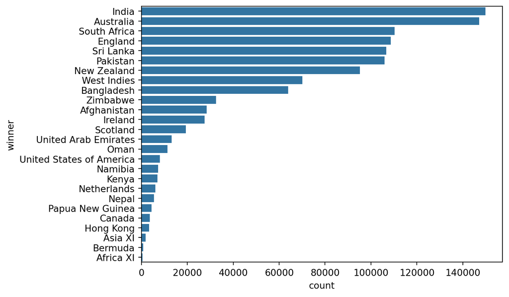

```python
info = pd.read_csv('data/ODI_Match_info.csv')
info = info.rename(columns = {'id':'match_id'})

#append all files together
csv_files = ['data/output_1.csv','data/output_2.csv','data/output_3.csv','data/output_4.csv','data/output_5.csv','data/output_6.csv','data/output_7.csv','data/output_8.csv','data/output_9.csv']

matchData = pd.concat([pd.read_csv(f,low_memory=False) for f in csv_files ], ignore_index=True)

#merge frames on match ID column

totalData = pd.merge(matchData, info, on = 'match_id') #merge by identical column 'match_id'
totalData.drop(totalData.filter(regex='_y$').columns, axis=1, inplace=True) #drop duplicate columns

totalData = totalData.rename(columns = {'season_x':'season', 'venue_x':'venue'})

from02to22 = totalData[~totalData['season'].astype(str).str.startswith(('2023/2024','2023', '2022/23'))] #exclude 2023 data

from02to22
print(type(from02to22)) #confirm data is read in as a df
print(from02to22.shape) #confirm data shape
print(from02to22.dtypes) #understand the types of data in the df
print(from02to22.isna().sum()) #count NA values in columns
print(pd.DataFrame.describe(from02to22)) #descriptive function to look at dataframe)


winners = sns.countplot(data = from02to22, y = 'winner', order=from02to22['winner'].value_counts().index)
winners

# corr = sns.pairplot(from02to22)
# corr
```

## Data Cleaning

Here, during a thorough process of Data Cleaning, we dropped some columns which were largely empty and replaced some empties with ‘Unknown’.

```python
#drop columns that have more than 1Million NaNs

colNaCounts = from02to22.isna().sum()


columns_to_drop = colNaCounts[colNaCounts >= 1000000].index.tolist()

# Drop identified columns from the DataFrame
from02to22 = from02to22.drop(columns=columns_to_drop)


#revalue new winner column

from02to22['winnerTeam'] = from02to22.apply(lambda row: 'team1' if row['winner'] == row['team1'] else 'team2', axis=1)

from02to22['toss_winner'] = from02to22.apply(lambda row: 'team1' if row['toss_winner'] == row['team1'] else 'team2', axis=1)



#convert Nan cities to 'Unknown'
#drop winner NA columns
#convert NA player of match to 'unknown'
#convert NA umpire 3 to 'unknown'

from02to22['city'] = from02to22['city'].fillna('Unknown')
from02to22['player_of_match'] = from02to22['player_of_match'].fillna('Unknown')
from02to22['umpire3'] = from02to22['umpire3'].fillna('Unknown')
from02to22 = from02to22.dropna(subset=['winner'])
from02to22 = from02to22.drop(columns = ['match_id', 'start_date', 'date', 'winner', 'cricsheet_id', 'season', 'venue', 'city', 'player_of_match', 'win_by_runs', 'win_by_wickets', 'umpire1', 'umpire2', 'umpire3', 'result']) #is date specific data really useful? also drop continuous match identifiers. We want the match stats
# corr = sns.pairplot(from02to22)
# corr
```

## Updated feature engineering

```python
import joblib

to_norm = (from02to22.select_dtypes(include =['int64', 'float64']))
to_encode = (from02to22.select_dtypes(include =['object']))

cricDataSet = from02to22.copy()

label_encoder = LabelEncoder()
min_max_scaler = MinMaxScaler()

label_encoders = {}

for col in cricDataSet.columns:
    if cricDataSet[col].dtype == 'object':  # Check if column is categorical
        label_encoders[col] = LabelEncoder()
        label_encoders[col].fit(cricDataSet[col])
        cricDataSet[col] = label_encoders[col].transform(cricDataSet[col])

# Save label encoder and scaler objects to disk
for col, encoder in label_encoders.items():
    joblib.dump(encoder, f'data/label_encoder_{col}.joblib')

cricDataSet[['innings', 'ball', 'runs_off_bat', 'extras', 'dl_applied']] = min_max_scaler.fit_transform(cricDataSet[['innings', 'ball', 'runs_off_bat', 'extras', 'dl_applied']])

# # Save label encoder and scaler objects to disk
# with open("data/label_encoder.pkl", "wb") as f:
#     pickle.dump(label_encoder, f)

# with open("data/min_max_scaler.pkl", "wb") as f:
#     pickle.dump(min_max_scaler, f)

joblib.dump(label_encoder, 'data/label_encoder.joblib')
joblib.dump(min_max_scaler, 'data/min_max_scaler.joblib')

from02to22.head()
```

|  | innings | ball | batting_team | bowling_team | striker | non_striker | bowler | runs_off_bat | extras | team1 | team2 | toss_winner | toss_decision | dl_applied | winnerTeam |
| --- | --- | --- | --- | --- | --- | --- | --- | --- | --- | --- | --- | --- | --- | --- | --- |
| 94186 | 1 | 0.1 | Namibia | Papua New Guinea | L Louwrens | D la Cock | N Pokana | 4 | 0 | Namibia | Papua New Guinea | team1 | bat | 0 | team1 |
| 94187 | 1 | 0.2 | Namibia | Papua New Guinea | L Louwrens | D la Cock | N Pokana | 0 | 1 | Namibia | Papua New Guinea | team1 | bat | 0 | team1 |
| 94188 | 1 | 0.3 | Namibia | Papua New Guinea | L Louwrens | D la Cock | N Pokana | 0 | 0 | Namibia | Papua New Guinea | team1 | bat | 0 | team1 |
| 94189 | 1 | 0.4 | Namibia | Papua New Guinea | L Louwrens | D la Cock | N Pokana | 0 | 0 | Namibia | Papua New Guinea | team1 | bat | 0 | team1 |
| 94190 | 1 | 0.5 | Namibia | Papua New Guinea | L Louwrens | D la Cock | N Pokana | 0 | 0 | Namibia | Papua New Guinea | team1 | bat | 0 | team1 |

```python
cricDataSet
```

|  | innings | ball | batting_team | bowling_team | striker | non_striker | bowler | runs_off_bat | extras | team1 | team2 | toss_winner | toss_decision | dl_applied | winnerTeam |
| --- | --- | --- | --- | --- | --- | --- | --- | --- | --- | --- | --- | --- | --- | --- | --- |
| 94186 | 0.0 | 0.000000 | 13 | 19 | 819 | 339 | 810 | 0.571429 | 0.000000 | 11 | 18 | 0 | 0 | 0.0 | 0 |
| 94187 | 0.0 | 0.002008 | 13 | 19 | 819 | 339 | 810 | 0.000000 | 0.166667 | 11 | 18 | 0 | 0 | 0.0 | 0 |
| 94188 | 0.0 | 0.004016 | 13 | 19 | 819 | 339 | 810 | 0.000000 | 0.000000 | 11 | 18 | 0 | 0 | 0.0 | 0 |
| 94189 | 0.0 | 0.006024 | 13 | 19 | 819 | 339 | 810 | 0.000000 | 0.000000 | 11 | 18 | 0 | 0 | 0.0 | 0 |
| 94190 | 0.0 | 0.008032 | 13 | 19 | 819 | 339 | 810 | 0.000000 | 0.000000 | 11 | 18 | 0 | 0 | 0.0 | 0 |
| ... | ... | ... | ... | ... | ... | ... | ... | ... | ... | ... | ... | ... | ... | ... | ... |
| 1265098 | 1.0 | 0.853414 | 10 | 16 | 622 | 1600 | 867 | 0.000000 | 0.000000 | 14 | 9 | 1 | 1 | 0.0 | 0 |
| 1265099 | 1.0 | 0.863454 | 10 | 16 | 1611 | 618 | 583 | 0.142857 | 0.000000 | 14 | 9 | 1 | 1 | 0.0 | 0 |
| 1265100 | 1.0 | 0.865462 | 10 | 16 | 622 | 1600 | 583 | 0.000000 | 0.000000 | 14 | 9 | 1 | 1 | 0.0 | 0 |
| 1265101 | 1.0 | 0.867470 | 10 | 16 | 1611 | 15 | 583 | 0.285714 | 0.000000 | 14 | 9 | 1 | 1 | 0.0 | 0 |
| 1265102 | 1.0 | 0.869478 | 10 | 16 | 1611 | 15 | 583 | 0.000000 | 0.000000 | 14 | 9 | 1 | 1 | 0.0 | 0 |

1138948 rows × 15 columns

## Feature Engineering

The next step is the Feature Engineering where we: - Normalized the continuous data - Encoded categorical variables

```python
#normalize continuous data because we dont have a normal distribution

to_norm = (from02to22.select_dtypes(include =['int64', 'float64'])) #select continuous variables

continuous = MinMaxScaler().fit_transform(to_norm) #fit and transform min max scaler (normalizes)
continuous = pd.DataFrame(continuous, index = from02to22.index, columns = list(to_norm))

#encode categorical variables

to_encode = (from02to22.select_dtypes(include =['object'])) #test if anything is an object or category variable

label_encoders = [] #make new encoder for each column
encoded_data = pd.DataFrame()

encoding_dicts = {}

# Iterate over each column in 'to_encode' and encode using a separate LabelEncoder
for col in to_encode:
    # Create a new instance of LabelEncoder for the current column
    encoder = LabelEncoder()

    # Fit and transform the data in 'from02to22[col]'
    encoded_data[col] = encoder.fit_transform(from02to22[col])

    # Store the encoder in the list
    label_encoders.append(encoder)

    encoding_dicts[col] = dict(zip(encoder.classes_, encoder.transform(encoder.classes_)))


#patch the columns back together

data = pd.concat([encoded_data.reset_index(drop=True), continuous.reset_index(drop=True)], axis = 1) #reset indices to avoid errors in concat
```

## Feature Selection

```python
X = cricDataSet.drop('winnerTeam', axis = 1) #input
y = cricDataSet['winnerTeam'] #target

selector = SelectKBest(score_func= f_classif, k = 10)
top10 = selector.fit_transform(X,y) #create variable that is the top 10 best feautures
cols_idxs = selector.get_support(indices=True) #grab indices from feature cols, get_support is from **sklearn**
top10 = X.iloc[:,cols_idxs] #add columns from whole dataset to the selected columns dataset https://stackoverflow.com/questions/39839112/the-easiest-way-for-getting-feature-names-after-running-selectkbest-in-scikit-le
top10.head()
```

|  | ball | batting_team | bowling_team | non_striker | bowler | runs_off_bat | team1 | team2 | toss_winner | dl_applied |
| --- | --- | --- | --- | --- | --- | --- | --- | --- | --- | --- |
| 94186 | 0.000000 | 13 | 19 | 339 | 810 | 0.571429 | 11 | 18 | 0 | 0.0 |
| 94187 | 0.002008 | 13 | 19 | 339 | 810 | 0.000000 | 11 | 18 | 0 | 0.0 |
| 94188 | 0.004016 | 13 | 19 | 339 | 810 | 0.000000 | 11 | 18 | 0 | 0.0 |
| 94189 | 0.006024 | 13 | 19 | 339 | 810 | 0.000000 | 11 | 18 | 0 | 0.0 |
| 94190 | 0.008032 | 13 | 19 | 339 | 810 | 0.000000 | 11 | 18 | 0 | 0.0 |

```python
X.columns
```

```
Index(['innings', 'ball', 'batting_team', 'bowling_team', 'striker',
       'non_striker', 'bowler', 'runs_off_bat', 'extras', 'team1', 'team2',
       'toss_winner', 'toss_decision', 'dl_applied'],
      dtype='object')
```

```python
#split data into training and testing


#break into 4 groups for testing and training, make the training dataset 70% of the data and the testing dataset 30% https://builtin.com/data-science/train-test-split
# X_train, X_test, y_train, y_test = tts(top10, y, test_size = 0.2)


X_train, X_test, y_train, y_test = tts(X, y, test_size = 0.2)

#PCA
# pca = PCA(n_components = 5) #go from 10 components to 5 components
# X_train_pca = pca.fit_transform(X_train)
# X_test_pca = pca.transform(X_test)

# X_train = X_train_pca
# X_test = X_test_pca

#training and testing models

 #decision tree
# lr = LogisticRegression()

# lr.fit(X_train,
#           y_train)
# predictLR = lr.predict(X_test)
# outcomeLR = pd.DataFrame ({'Actual': y_test, 'Predicted': predictLR})
# outcomeLR['Actual'] = label_encoders[9].inverse_transform(outcomeLR['Actual'])
# outcomeLR['Predicted'] = label_encoders[9].inverse_transform(outcomeLR['Predicted'])

# key = (label_encoders[9].classes_)
```

## Model Validation

```python
# #Evaluating models
# #logistic regression
# cvLR = cross_validate(lr,X_train, y_train)
# print("cross validation of logistic regression", cvLR)
# print("accuracy of logistic regression:", metrics.accuracy_score(y_test, predictLR)) #testing how accuracy of the models
# print("precision of logistic regression:", metrics.precision_score(y_test, predictLR, average = 'weighted'))
# print("recall of logistic regression:", metrics.recall_score(y_test, predictLR, average = 'weighted'))
# print("f1 of logistic regression:", metrics.f1_score(y_test, predictLR, average = 'weighted'))
# print("ROCAUC macro of logistic regression:", metrics.roc_auc_score(y_test, predictLR))
# print("ROCAUC micro of logistic regression:", metrics.roc_auc_score(y_test, predictLR, average = 'micro'))


# y_pred_proba = lr.predict_proba(X_test)[::,1] #https://www.statology.org/plot-roc-curve-python/
# fpr, tpr, _ = metrics.roc_curve(y_test,  y_pred_proba)
# plt.plot(fpr,tpr)
# plt.ylabel('True Positive Rate')
# plt.xlabel('False Positive Rate')
# plt.title('ROC Curve Logistic Regression')
# plt.show()

# print('')
```

### Random Forest Classifier

```python
#random forest
rfc = RandomForestClassifier(criterion='gini')
rfc.fit(X_train,
          y_train)
# # predictRFC = rfc.predict(X_test)
# # outcomeRFC = pd.DataFrame ({'Actual': y_test, 'Predicted': predictRFC})
# # outcomeRFC['Actual'] = label_encoders[9].inverse_transform(outcomeRFC['Actual'])
# # outcomeRFC['Predicted'] = label_encoders[9].inverse_transform(outcomeRFC['Predicted'])

# #Evaluating models
# #random forest
# cvRF = cross_validate(rfc,X_train, y_train)
# print("cross validation of random forest", cvRF)
# print("accuracy of random forest:", metrics.accuracy_score(y_test, predictRFC)) #testing how accuracy of the models
# print("precision of random forest:", metrics.precision_score(y_test, predictRFC, average = 'weighted'))
# print("recall of random forest:", metrics.recall_score(y_test, predictRFC, average = 'weighted'))
# print("f1 of random forest:", metrics.f1_score(y_test, predictRFC, average = 'weighted'))
# print("ROCAUC macro of random forest:", metrics.roc_auc_score(y_test, predictRFC))
# print("ROCAUC micro of random forest:", metrics.roc_auc_score(y_test, predictRFC, average = 'micro'))


# y_pred_proba = rfc.predict_proba(X_test)[::,1]
# fpr, tpr, _ = metrics.roc_curve(y_test,  y_pred_proba)
# plt.plot(fpr,tpr)
# plt.ylabel('True Positive Rate')
# plt.xlabel('False Positive Rate')
# plt.title('ROC Curve Random Forest')
# plt.show()

#FOR LOCAL USE
# Step 2: Save the trained model to a pickle file
# with open("/Users/cortmann/Desktop/523 - Data Mining/localCricketPredictions/cricketPrediction.pkl", "wb") as f:
#     pickle.dump(rfc, f)
```

```
RandomForestClassifier()
```

```python
from sklearn.metrics import accuracy_score
yPred = rfc.predict(X_test)



# Calculate the accuracy of the model
accuracy = accuracy_score(y_test, yPred)
print("Accuracy:", accuracy * 100, "%")
```

```
Accuracy: 98.96878704069537 %
```

## Feed 2023 Data

Now we feed the live data (which is the 2023 match data), through back end API, at regular intervals, thereby changing the stats everytime. And each time a statistic is updated, the prediction updates as well.

```python
# Step 2: Save the trained model to a pickle file
with open("data/cricketPrediction.pkl", "wb") as f:
    pickle.dump(rfc, f)



# Step 3: Load the model from the pickle file

# with open("linear_regression_model.pkl", "rb") as f:
#     loaded_model = pickle.load(f)
```

## Model Implementation

Finally, we display the model predictionm on a webpage and take you through our journey of prediction!

```python
loaded_model = None

# Load the model from the pickle file
with open("data/cricketPrediction.pkl", "rb") as f:
    loaded_model = pickle.load(f)

predictRFC = loaded_model.predict(X_test)

outcomeRFC = pd.DataFrame ({'Actual': y_test, 'Predicted': predictRFC})
outcomeRFC['Actual'] = label_encoders[9].inverse_transform(outcomeRFC['Actual'])
outcomeRFC['Predicted'] = label_encoders[9].inverse_transform(outcomeRFC['Predicted'])



# cvRF = cross_validate(loaded_model,X_train, y_train)
# print("cross validation of random forest", cvRF)
# print("accuracy of random forest:", metrics.accuracy_score(y_test, predictRFC)) #testing how accuracy of the models
# print("precision of random forest:", metrics.precision_score(y_test, predictRFC, average = 'weighted'))
# print("recall of random forest:", metrics.recall_score(y_test, predictRFC, average = 'weighted'))
# print("f1 of random forest:", metrics.f1_score(y_test, predictRFC, average = 'weighted'))
# print("ROCAUC macro of random forest:", metrics.roc_auc_score(y_test, predictRFC))
# print("ROCAUC micro of random forest:", metrics.roc_auc_score(y_test, predictRFC, average = 'micro'))


# y_pred_proba = loaded_model.predict_proba(X_test)[::,1]
# fpr, tpr, _ = metrics.roc_curve(y_test,  y_pred_proba)
# plt.plot(fpr,tpr)
# plt.ylabel('True Positive Rate')
# plt.xlabel('False Positive Rate')
# plt.title('ROC Curve Random Forest')
# plt.show()
```

```python
import json

teams = pd.concat([from02to22['team1'], from02to22['team2']]).unique()

# Create a dictionary mapping each team to a unique number
team_map = {team: i+1 for i, team in enumerate(teams)}

players = pd.concat([from02to22['striker'], from02to22['non_striker'], from02to22['bowler']]).unique()

player_map = {player: i+1 for i, player in enumerate(players)}

with open('data/team_map.json', 'w') as f:
    json.dump(team_map, f)

with open('data/player_map.json', 'w') as f:
    json.dump(player_map, f)
```

```python
# Load the team map dictionary from the saved JSON file
with open('data/team_map.json', 'r') as f:
    team_map_loaded = json.load(f)

with open('data/player_map.json', 'r') as f:
    player_map_loaded = json.load(f)

temp = from02to22.copy()

team_map_loaded = dict(team_map_loaded)
player_map_loaded = dict(player_map_loaded)

temp['team1'] = temp['team1'].apply(lambda x: team_map_loaded.get(x))

temp['team2'] = temp['team2'].apply(lambda x: team_map_loaded.get(x))

temp['batting_team'] = temp['batting_team'].apply(lambda x: team_map_loaded.get(x))

temp['bowling_team'] = temp['bowling_team'].apply(lambda x: team_map_loaded.get(x))

temp['striker'] = temp['striker'].apply(lambda x: player_map_loaded.get(x))

temp['non_striker'] = temp['non_striker'].apply(lambda x: player_map_loaded.get(x))

temp['bowler'] = temp['bowler'].apply(lambda x: player_map_loaded.get(x))

temp['toss_winner'] = temp['toss_winner'].apply(lambda x: 0 if x == "team1" else 1)

temp['winnerTeam'] = temp['winnerTeam'].apply(lambda x: 0 if x == "team1" else 1)

temp['toss_decision'] = temp['toss_decision'].apply(lambda x: 0 if x == "bat" else 1)
```

```python
min_max_scaler = MinMaxScaler()

temp[['innings', 'ball', 'runs_off_bat', 'extras', 'dl_applied']] = min_max_scaler.fit_transform(temp[['innings', 'ball', 'runs_off_bat', 'extras', 'dl_applied']])

joblib.dump(min_max_scaler, 'data/min_max_scaler.joblib')
```

```
['data/min_max_scaler.joblib']
```

```python
cricDataSet = temp.copy()

X = cricDataSet.drop('winnerTeam', axis = 1) #input
y = cricDataSet['winnerTeam'] #target

X_train, X_test, y_train, y_test = tts(X, y, test_size = 0.2)

rfc = RandomForestClassifier(criterion='gini')
rfc.fit(X_train,
          y_train)
```

```
RandomForestClassifier()
```

```python
from sklearn.metrics import accuracy_score
yPred = rfc.predict(X_test)

# Calculate the accuracy of the model
accuracy = accuracy_score(y_test, yPred)
print("Accuracy:", accuracy * 100, "%")
```

```
Accuracy: 99.04473418499495 %
```

```python
# Step 2: Save the trained model to a pickle file
with open("data/cricketPrediction.pkl", "wb") as f:
    pickle.dump(rfc, f)
```

```python
import requests
import pandas as pd

loaded_model = None

with open("data/cricketPrediction.pkl", "rb") as f:
    loaded_model = pickle.load(f)



mainUrl = "http://127.0.0.1:8100"

getEntireLiveDataApi = "/analyzingtrends/getentirelivedata"
getCurrentLiveDataApi = "/analyzingtrends/getcurrentlivedata"



def getAllLiveData():
  response = requests.get(mainUrl + getEntireLiveDataApi)

  liveData = []

  if response.status_code == 200:  # Check if the request was successful
      json_data = response.json()  # Convert response to JSON format
      liveData = pd.DataFrame(json_data)
  else:
      print("Failed to retrieve data from the API.")

  return liveData

def getCurrentLiveData():
  response = requests.get(mainUrl + getCurrentLiveDataApi)
  liveList = []
  liveData = None
  json_data = None

  if response.status_code == 200:  # Check if the request was successful
      json_data = response.json()  # Convert response to JSON format
      liveList.append(json_data)
      liveData = pd.DataFrame(liveList)
  else:
      print("Failed to retrieve data from the API.")

  return liveData, json_data


def processLiveFeed():

    liveData0, liveJson = getCurrentLiveData()
    liveData0 = getAllLiveData()

    new_columns = ['match_id', 'season', 'venue', 'innings', 'ball', 'batting_team',
                'bowling_team', 'striker', 'non_striker', 'bowler', 'runs_off_bat',
                'extras', 'wides', 'noballs', 'city', 'date', 'team1', 'team2',
                'toss_winner', 'toss_decision', 'result', 'dl_applied', 'winner',
                'win_by_runs', 'win_by_wickets', 'player_of_match', 'total_runs', 'id']

    # Rename columns
    liveData0.columns = new_columns
    liveData = liveData0.filter(['innings', 'ball', 'batting_team', 'bowling_team', 'striker',
       'non_striker', 'bowler', 'runs_off_bat', 'extras', 'team1', 'team2',
       'toss_winner', 'toss_decision', 'dl_applied'])


    liveData['toss_winner'] = liveData.apply(lambda row: 'team1' if row['toss_winner'] == row['team1'] else 'team2', axis=1)


    # Load the team map dictionary from the saved JSON file
    with open('data/team_map.json', 'r') as f:
        team_map_loaded = json.load(f)

    with open('data/player_map.json', 'r') as f:
        player_map_loaded = json.load(f)

    team_map_loaded = dict(team_map_loaded)
    player_map_loaded = dict(player_map_loaded)

    liveData['team1'] = liveData['team1'].apply(lambda x: team_map_loaded.get(x))

    liveData['team2'] = liveData['team2'].apply(lambda x: team_map_loaded.get(x))

    liveData['batting_team'] = liveData['batting_team'].apply(lambda x: team_map_loaded.get(x))

    liveData['bowling_team'] = liveData['bowling_team'].apply(lambda x: team_map_loaded.get(x))

    liveData['striker'] = liveData['striker'].apply(lambda x: player_map_loaded.get(x))

    liveData['non_striker'] = liveData['non_striker'].apply(lambda x: player_map_loaded.get(x))

    liveData['bowler'] = liveData['bowler'].apply(lambda x: player_map_loaded.get(x))

    liveData['toss_winner'] = liveData['toss_winner'].apply(lambda x: 0 if x == "team1" else 1)

    liveData['toss_decision'] = liveData['toss_decision'].apply(lambda x: 0 if x == "bat" else 1)

    loaded_min_max_scaler = joblib.load('data/min_max_scaler.joblib')

    liveData[['innings', 'ball', 'runs_off_bat', 'extras', 'dl_applied']] = loaded_min_max_scaler.transform(liveData[['innings', 'ball', 'runs_off_bat', 'extras', 'dl_applied']])


    predictRFC = loaded_model.predict(liveData)

    # Apply mapping function directly to the predicted values (assuming predictRFC is a Series or array)
    print(predictRFC)
    out = pd.Series(predictRFC).apply(map_team)
    out = pd.DataFrame(out)
    out['match_id'] = liveData0['match_id']
    print(liveData.head())

    # countTeamPrediction = Counter(out[0])

    # print(countTeamPrediction)

    return out, liveJson, predictRFC

def map_team(value):
    if value == 0:
        return 'team1'
    else:
        return 'team2'


def getPredictionPercent(out):
    out = dict(out)
    team1 = out.get("team1")
    team2 = out.get("team2")

    if(team1 == None):
        team1 = 0

    if(team2 == None):
        team2 = 0

    liveData0, liveJson = getCurrentLiveData()

    team1Name = liveJson.get("team1")
    team2Name = liveJson.get("team2")

    print(team1)
    print(team2)

    return int(team1), int(team2), team1Name, team2Name
```

```python
# out, liveJson, predictRFC = processLiveFeed()

# team1, team2, team1Name, team2Name = getPredictionPercent(out)

# zeros = np.count_nonzero(predictRFC == 0)
# total = len(predictRFC)
# ones = total - zeros

# percTeam1 = (zeros/total) * 100
# percTeam2 = 100 - percTeam1

# print(percTeam1)
# print(percTeam2)
```